# CMPINF 2130 Summer 2021 - Week 08

### Conditioning

We can condition a scatter plot on a categorical variable. First look at iris sepal variables per Species.

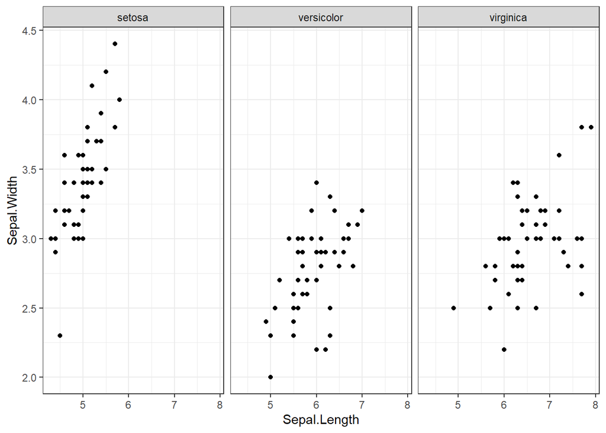

```r
iris %>%
  ggplot(mapping = aes(x = Sepal.Length, y = Sepal.Width)) +
  geom_point() +
  facet_wrap(~Species) +
  theme_bw()
```

We can visualize the joint distribution as a 2D histogram for separate levels of a categorical.

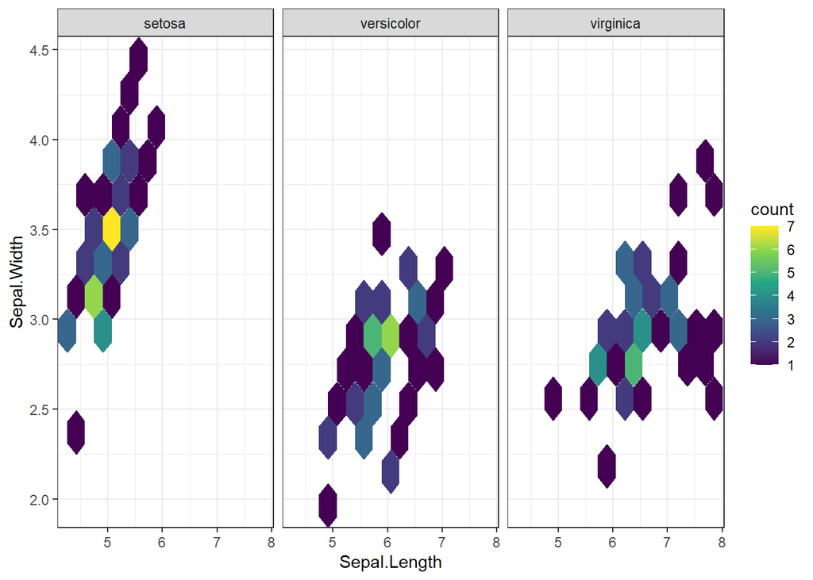

```r
iris %>%
  ggplot(mapping = aes(x = Sepal.Length, y = Sepal.Width)) +
  geom_hex(bins = 11) +
  facet_wrap(~Species) +
  scale_fill_viridis_c() +
  theme_bw()
```

Use the `cut` variable as the grouping categorical variable in `diamonds`.

```r
diamonds %>% dplyr::count(cut)
```

```
## # A tibble: 5 x 2
##   cut           n
##   <ord>     <int>
## 1 Fair       1610
## 2 Good       4906
## 3 Very Good 12082
## 4 Premium   13791
## 5 Ideal     21551
```

Condition the hexbin plot of `price` and `carat` on `cut`.

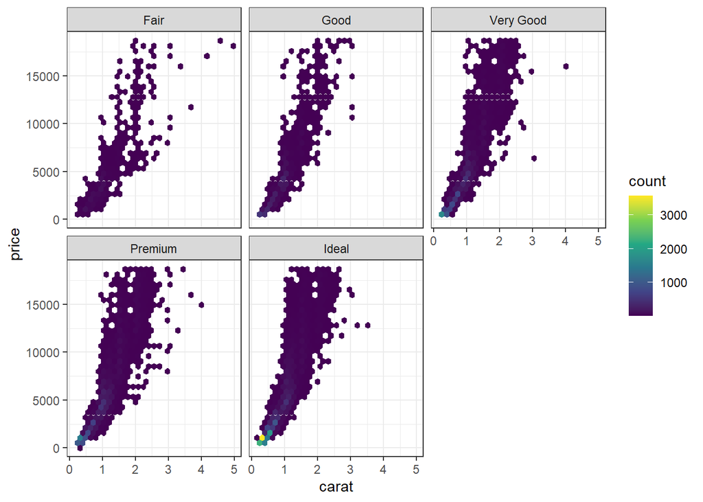

```r
diamonds %>%
  ggplot(mapping = aes(x = carat, y = price)) +
  geom_hex() +
  facet_wrap(~cut) +
  scale_fill_viridis_c() +
  theme_bw()
```

We can scale the fill color relative to the max count per faceting variable group.

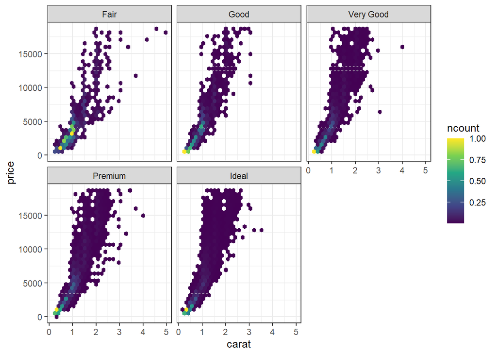

```r
diamonds %>%
  ggplot(mapping = aes(x = carat, y = price)) +
  geom_hex(mapping = aes(fill = stat(ncount))) +
  facet_wrap(~cut) +
  scale_fill_viridis_c() +
  theme_bw()
```

Check by filtering to the `cut == 'Fair'`.

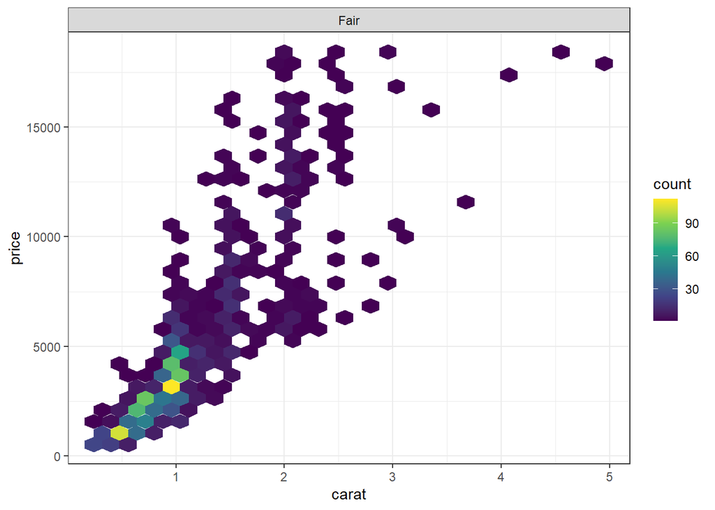

```r
diamonds %>%
  dplyr::filter(cut == "Fair") %>%
  ggplot(mapping = aes(x = carat, y = price)) +
  geom_hex() +
  facet_wrap(~cut) +
  scale_fill_viridis_c() +
  theme_bw()
```

We can also us a kernel density estimate to smooth out the counts of a histogram.

Let’s first see the 2D density estimate for iris.

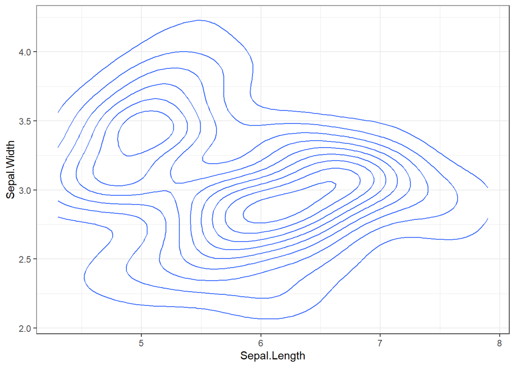

```r
iris %>%
  ggplot(mapping = aes(x = Sepal.Length, y = Sepal.Width)) +
  geom_density_2d() +
  theme_bw()
```

We can overlay the scatter plot to confirm the contour behavior.

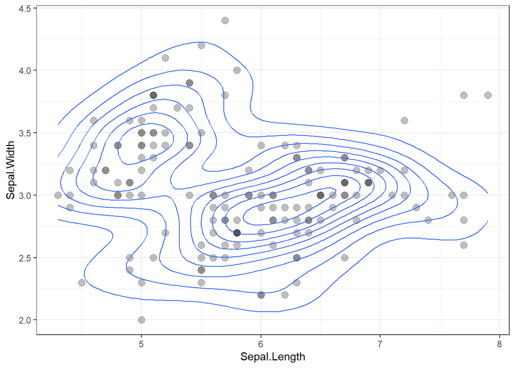

```r
iris %>%
  ggplot(mapping = aes(x = Sepal.Length, y = Sepal.Width)) +
  geom_point(size = 3, alpha = 0.25) +
  geom_density_2d() +
  theme_bw()
```

Alternatively we can compare the 2D histogram with the 2D density estimate.

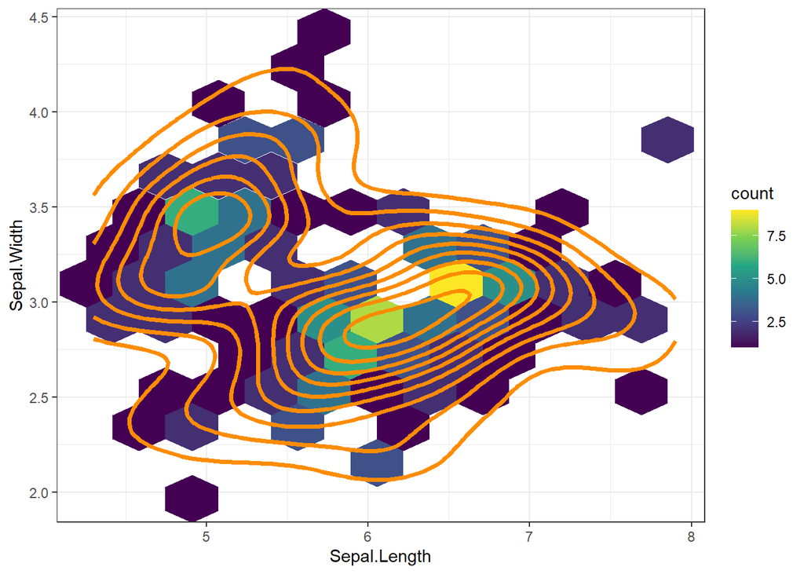

```r
iris %>%
  ggplot(mapping = aes(x = Sepal.Length, y = Sepal.Width)) +
  geom_hex(bins=11) +
  geom_density_2d(color = 'darkorange', size = 1.25) +
  scale_fill_viridis_c() +
  theme_bw()
```

We can also use a filled in contour plot if we would like.

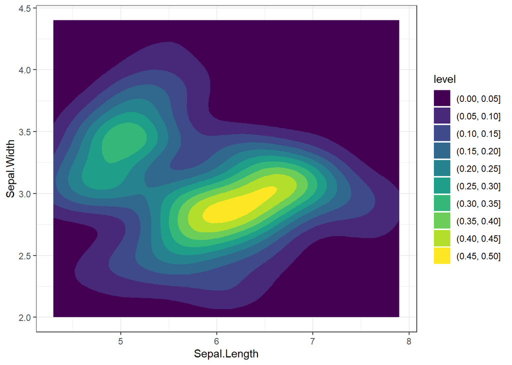

```r
iris %>%
  ggplot(mapping = aes(x = Sepal.Length, y = Sepal.Width)) +
  geom_density_2d_filled() +
  theme_bw()
```

We can also condition the 2D density estimate on a categorical variable.

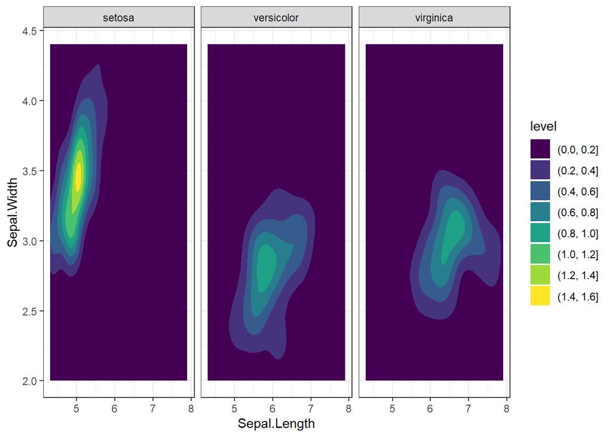

```r
iris %>%
  ggplot(mapping = aes(x = Sepal.Length, y = Sepal.Width)) +
  geom_density_2d_filled() +
  facet_wrap(~Species) +
  theme_bw()
```

And so we may instead prefer to use a relative fill scale to focus on the combinations with the highest relative density in each facet.

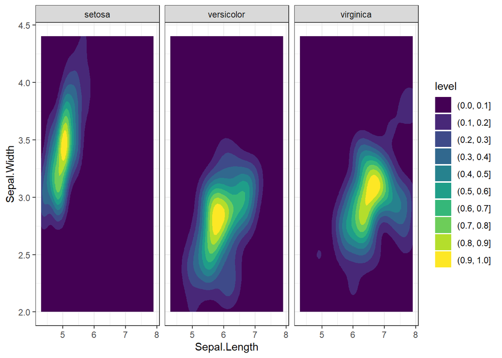

```r
iris %>%
  ggplot(mapping = aes(x = Sepal.Length, y = Sepal.Width)) +
  geom_density_2d_filled(contour_var = 'ndensity') +
  facet_wrap(~Species) +
  theme_bw()
```

Alternatively, we can overlay densities on a single plot colored by the categorical variable.

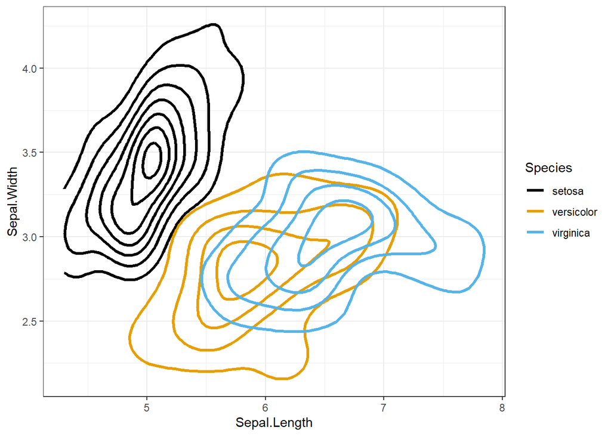

```r
iris %>%
  ggplot(mapping = aes(x = Sepal.Length, y = Sepal.Width)) +
  geom_density_2d(mapping = aes(color = Species),
                  size = 1.1) +
  ggthemes::scale_color_colorblind() +
  theme_bw()
```

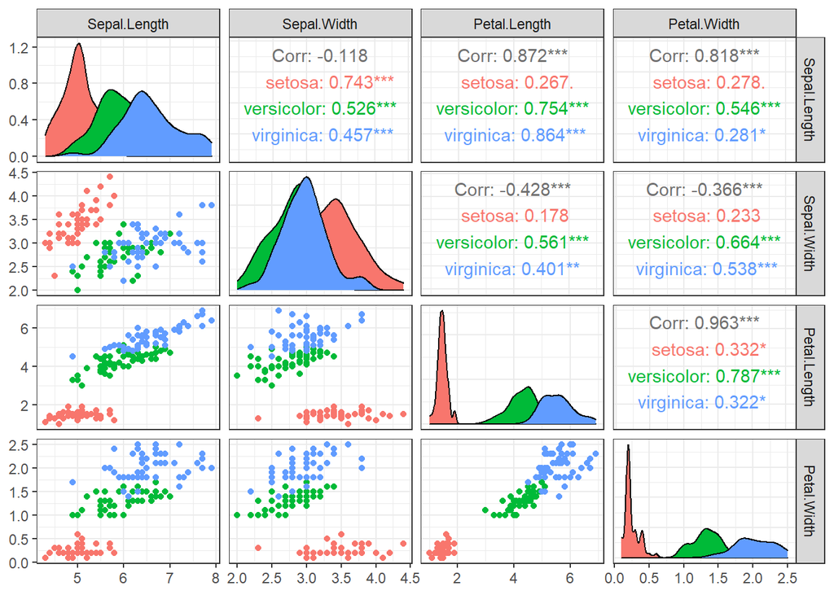

```r
iris %>%
  ggpairs(columns = 1:4,
          progress = FALSE,
          mapping = aes(color = Species)) +
  theme_bw()
```

Instead use a 2D density estimate, but it is important to use the `ndensity` to compare the relative heights across the categorical groups.

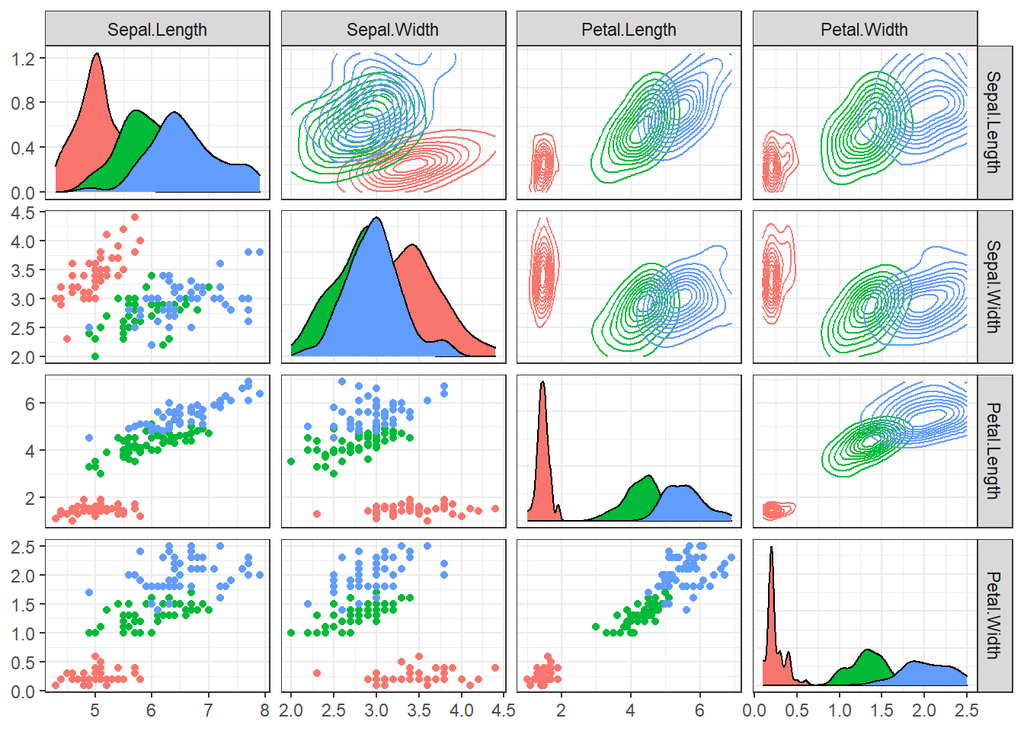

```r
iris %>%
  ggpairs(columns = 1:4,
          progress = FALSE,
          mapping = aes(color = Species),
          upper = list(continuous = wrap('density',
                                         contour_var = 'ndensity',
                                         adjust = 1.5))) +
  theme_bw()
```

There are other options we can consider for how to display the diagonal and off-diagonal subplots within a pairs plot. Please see the `ggpairs()` documentation to learn more.

[ggpairs main reference](https://ggobi.github.io/ggally/reference/ggpairs.html)

[ggpairs function types](https://ggobi.github.io/ggally/articles/ggally_plots.html)